# Quantium Data Analytics Project - Task 2

## 1. UNDERSTAND THE PROBLEM STATEMENT

For this part of the project we will be examining the performance in trial vs control stores to provide a recommendation for each location based on our insight. Below are some of the areas I want you to focus on, of course if you discover any other interesting insights feel free to include them in your findings.

- Select control stores – explore the data and define metrics for your control store selection – think about what would make them a control store. Look at the drivers and make sure you visualise these in a graph to better determine if they are suited. For this piece it may even be worth creating a function to help you.
- Assessment of the trial – this one should give you some interesting insights into each of the stores, check each trial store individually in comparison with the control store to get a clear view of its overall performance. We want to know if the trial stores were successful or not.
- Collate findings – summarise your findings for each store and provide an recommendation that we can share with Julia outlining the impact on sales during the trial period.
- Remember when working with a client visualisations are key to helping them understand the data. Be sure to save all your visualisations so we can use them later in our report. We are presenting to our client in 3 weeks so if you could submit your analysis by mid next week that will give us great amount of time to discuss findings and pull together the report.

## 2. IMPORT LIBRARIES AND READ DATASET

```python
import pandas as pd
import numpy as np
import matplotlib.pyplot as plt
import seaborn as sns
from scipy import stats
import warnings
warnings.filterwarnings("ignore")
```

```python
df = pd.read_csv('QVI_data.csv')
```

```python
df.shape
```

```
(264834, 12)
```

```python
df.head()
```

|  | LYLTY_CARD_NBR | DATE | STORE_NBR | TXN_ID | PROD_NBR | PROD_NAME | PROD_QTY | TOT_SALES | PACK_SIZE | BRAND | LIFESTAGE | PREMIUM_CUSTOMER |
| --- | --- | --- | --- | --- | --- | --- | --- | --- | --- | --- | --- | --- |
| 0 | 1000 | 2018-10-17 | 1 | 1 | 5 | Natural Chip Compny SeaSalt175g | 2 | 6.0 | 175 | NATURAL | YOUNG SINGLES/COUPLES | Premium |
| 1 | 1002 | 2018-09-16 | 1 | 2 | 58 | Red Rock Deli Chikn&Garlic Aioli 150g | 1 | 2.7 | 150 | RRD | YOUNG SINGLES/COUPLES | Mainstream |
| 2 | 1003 | 2019-03-07 | 1 | 3 | 52 | Grain Waves Sour Cream&Chives 210G | 1 | 3.6 | 210 | GRNWVES | YOUNG FAMILIES | Budget |
| 3 | 1003 | 2019-03-08 | 1 | 4 | 106 | Natural ChipCo Hony Soy Chckn175g | 1 | 3.0 | 175 | NATURAL | YOUNG FAMILIES | Budget |
| 4 | 1004 | 2018-11-02 | 1 | 5 | 96 | WW Original Stacked Chips 160g | 1 | 1.9 | 160 | WOOLWORTHS | OLDER SINGLES/COUPLES | Mainstream |

```python
df.info()
```

```
<class 'pandas.core.frame.DataFrame'>
RangeIndex: 264834 entries, 0 to 264833
Data columns (total 12 columns):
 #   Column            Non-Null Count   Dtype
---  ------            --------------   -----
 0   LYLTY_CARD_NBR    264834 non-null  int64
 1   DATE              264834 non-null  object
 2   STORE_NBR         264834 non-null  int64
 3   TXN_ID            264834 non-null  int64
 4   PROD_NBR          264834 non-null  int64
 5   PROD_NAME         264834 non-null  object
 6   PROD_QTY          264834 non-null  int64
 7   TOT_SALES         264834 non-null  float64
 8   PACK_SIZE         264834 non-null  int64
 9   BRAND             264834 non-null  object
 10  LIFESTAGE         264834 non-null  object
 11  PREMIUM_CUSTOMER  264834 non-null  object
dtypes: float64(1), int64(6), object(5)
memory usage: 24.2+ MB
```

```python
df.describe()
```

|  | LYLTY_CARD_NBR | STORE_NBR | TXN_ID | PROD_NBR | PROD_QTY | TOT_SALES | PACK_SIZE |
| --- | --- | --- | --- | --- | --- | --- | --- |
| count | 2.648340e+05 | 264834.000000 | 2.648340e+05 | 264834.000000 | 264834.000000 | 264834.000000 | 264834.000000 |
| mean | 1.355488e+05 | 135.079423 | 1.351576e+05 | 56.583554 | 1.905813 | 7.299346 | 182.425512 |
| std | 8.057990e+04 | 76.784063 | 7.813292e+04 | 32.826444 | 0.343436 | 2.527241 | 64.325148 |
| min | 1.000000e+03 | 1.000000 | 1.000000e+00 | 1.000000 | 1.000000 | 1.500000 | 70.000000 |
| 25% | 7.002100e+04 | 70.000000 | 6.760050e+04 | 28.000000 | 2.000000 | 5.400000 | 150.000000 |
| 50% | 1.303570e+05 | 130.000000 | 1.351365e+05 | 56.000000 | 2.000000 | 7.400000 | 170.000000 |
| 75% | 2.030940e+05 | 203.000000 | 2.026998e+05 | 85.000000 | 2.000000 | 9.200000 | 175.000000 |
| max | 2.373711e+06 | 272.000000 | 2.415841e+06 | 114.000000 | 5.000000 | 29.500000 | 380.000000 |

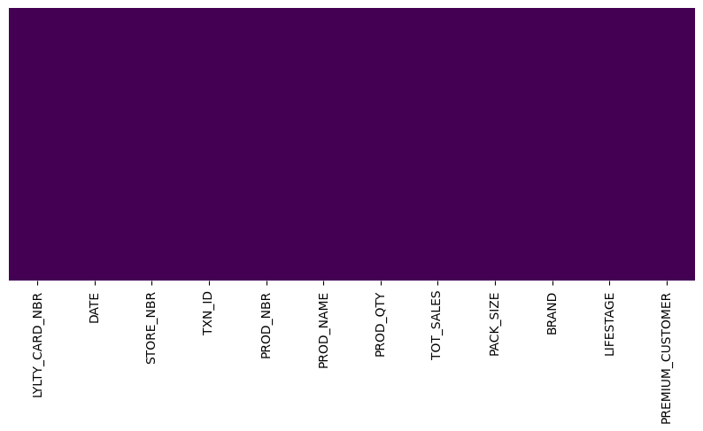

```python
plt.figure(figsize=(10,4))
sns.heatmap(df.isna(), yticklabels=False, cbar=False, cmap='viridis')
plt.show()
```

```python
df.duplicated().sum()
```

```
np.int64(1)
```

```python
df.drop_duplicates(inplace=True)
```

```python
df.shape
```

```
(264833, 12)
```

```python
# What should a good control store look like?

# A control store should have similar:

# 1. Total sales
# 2. Number of customers
# 3. Number of transactions
# 4. Average transactions per customer
# 5. Average units per transaction
# 6. Average price per unit

# These are the drivers you already calculated in preTrialMeasures.
```

```python
## Select Control Stores
```

The client has selected store numbers 77, 86 and 88 as trial stores and want control stores to be established stores that are operational for the entire observation period.

We would want to match trial stores to control stores that are similar to the trial store prior to the trial period of Feb 2019 in terms of :

- Monthly overall sales revenue
- Monthly number of customers
- Monthly number of transactions per customer

To choose the control stores, we will create the metrics of interest and filter to stores that are present throughout the pre-trial period.

First, we want to add a column with the year/month of the transaction.

```python
# Change DATE column to datetime
df['DATE'] = pd.to_datetime(df['DATE'])
```

```python
# Add a YEARMONTH column
df['YEARMONTH'] = df['DATE'].dt.strftime('%Y%m').astype('int64')
df
```

|  | LYLTY_CARD_NBR | DATE | STORE_NBR | TXN_ID | PROD_NBR | PROD_NAME | PROD_QTY | TOT_SALES | PACK_SIZE | BRAND | LIFESTAGE | PREMIUM_CUSTOMER | YEARMONTH |
| --- | --- | --- | --- | --- | --- | --- | --- | --- | --- | --- | --- | --- | --- |
| 0 | 1000 | 2018-10-17 | 1 | 1 | 5 | Natural Chip Compny SeaSalt175g | 2 | 6.0 | 175 | NATURAL | YOUNG SINGLES/COUPLES | Premium | 201810 |
| 1 | 1002 | 2018-09-16 | 1 | 2 | 58 | Red Rock Deli Chikn&Garlic Aioli 150g | 1 | 2.7 | 150 | RRD | YOUNG SINGLES/COUPLES | Mainstream | 201809 |
| 2 | 1003 | 2019-03-07 | 1 | 3 | 52 | Grain Waves Sour Cream&Chives 210G | 1 | 3.6 | 210 | GRNWVES | YOUNG FAMILIES | Budget | 201903 |
| 3 | 1003 | 2019-03-08 | 1 | 4 | 106 | Natural ChipCo Hony Soy Chckn175g | 1 | 3.0 | 175 | NATURAL | YOUNG FAMILIES | Budget | 201903 |
| 4 | 1004 | 2018-11-02 | 1 | 5 | 96 | WW Original Stacked Chips 160g | 1 | 1.9 | 160 | WOOLWORTHS | OLDER SINGLES/COUPLES | Mainstream | 201811 |
| ... | ... | ... | ... | ... | ... | ... | ... | ... | ... | ... | ... | ... | ... |
| 264829 | 2370701 | 2018-12-08 | 88 | 240378 | 24 | Grain Waves Sweet Chilli 210g | 2 | 7.2 | 210 | GRNWVES | YOUNG FAMILIES | Mainstream | 201812 |
| 264830 | 2370751 | 2018-10-01 | 88 | 240394 | 60 | Kettle Tortilla ChpsFeta&Garlic 150g | 2 | 9.2 | 150 | KETTLE | YOUNG FAMILIES | Premium | 201810 |
| 264831 | 2370961 | 2018-10-24 | 88 | 240480 | 70 | Tyrrells Crisps Lightly Salted 165g | 2 | 8.4 | 165 | TYRRELLS | OLDER FAMILIES | Budget | 201810 |
| 264832 | 2370961 | 2018-10-27 | 88 | 240481 | 65 | Old El Paso Salsa Dip Chnky Tom Ht300g | 2 | 10.2 | 300 | OLD | OLDER FAMILIES | Budget | 201810 |
| 264833 | 2373711 | 2018-12-14 | 88 | 241815 | 16 | Smiths Crinkle Chips Salt & Vinegar 330g | 2 | 11.4 | 330 | SMITHS | YOUNG SINGLES/COUPLES | Mainstream | 201812 |

264833 rows × 13 columns

```python
## Next, we define the measure calculations to use during the analysis
```

Define metrics and calculate total sales, number of customers, transactions per customer, chips per customer and the average price per unit for each store and month.

```python
# Define the mertrics
group_df = df.groupby(['STORE_NBR', 'YEARMONTH'])
total_sales = group_df['TOT_SALES'].sum()
num_cust = group_df['LYLTY_CARD_NBR'].nunique()
ntrans_per_cust = group_df['TXN_ID'].size()/num_cust
nchips_per_trans = group_df['PROD_QTY'].sum()/group_df['TXN_ID'].size()
avg_price_perunit = total_sales/group_df['PROD_QTY'].sum()
```

```python
avg_price_perunit
```

| STORE_NBR | YEARMONTH | 0 |
| --- | --- | --- |
| 1 | 201807 | 3.337097 |
|  | 201808 | 3.261111 |
|  | 201809 | 3.717333 |
|  | 201810 | 3.243103 |
|  | 201811 | 3.378947 |
| ... | ... | ... |
| 272 | 201902 | 4.346154 |
|  | 201903 | 4.379208 |
|  | 201904 | 4.239048 |
|  | 201905 | 4.430986 |
|  | 201906 | 4.458571 |

3169 rows × 1 columns

**dtype:** float64

```python
metrics_array = [total_sales, num_cust, ntrans_per_cust, nchips_per_trans, avg_price_perunit]
```

```python
# Create the metrics table
metrics_df = pd.concat(metrics_array, axis=1)
```

```python
# Create Column names
metrics_df.columns = ['total_sales', 'num_cust', 'ntrans_per_cust', 'nchips_per_trans', 'avg_price_perunit']
metrics_df = metrics_df.reset_index()
metrics_df
```

|  | STORE_NBR | YEARMONTH | total_sales | num_cust | ntrans_per_cust | nchips_per_trans | avg_price_perunit |
| --- | --- | --- | --- | --- | --- | --- | --- |
| 0 | 1 | 201807 | 206.9 | 49 | 1.061224 | 1.192308 | 3.337097 |
| 1 | 1 | 201808 | 176.1 | 42 | 1.023810 | 1.255814 | 3.261111 |
| 2 | 1 | 201809 | 278.8 | 59 | 1.050847 | 1.209677 | 3.717333 |
| 3 | 1 | 201810 | 188.1 | 44 | 1.022727 | 1.288889 | 3.243103 |
| 4 | 1 | 201811 | 192.6 | 46 | 1.021739 | 1.212766 | 3.378947 |
| ... | ... | ... | ... | ... | ... | ... | ... |
| 3164 | 272 | 201902 | 395.5 | 45 | 1.066667 | 1.895833 | 4.346154 |
| 3165 | 272 | 201903 | 442.3 | 50 | 1.060000 | 1.905660 | 4.379208 |
| 3166 | 272 | 201904 | 445.1 | 54 | 1.037037 | 1.875000 | 4.239048 |
| 3167 | 272 | 201905 | 314.6 | 34 | 1.176471 | 1.775000 | 4.430986 |
| 3168 | 272 | 201906 | 312.1 | 34 | 1.088235 | 1.891892 | 4.458571 |

3169 rows × 7 columns

```python
# Keep only stores that have data for all 12 months so that trial and control store comparisons are based on complete, consistent histories.
```

```python
## Filter to the pre-trial period and stores with full observation periods
month_count = metrics_df.groupby('STORE_NBR').YEARMONTH.nunique().reset_index()
storesWithFullObs = month_count[month_count.YEARMONTH ==12].STORE_NBR
preTrialMeasures = metrics_df[metrics_df['STORE_NBR'].isin(storesWithFullObs)]

# Filter to keep only the pre-trial period data
preTrialMeasures = preTrialMeasures.loc[preTrialMeasures.YEARMONTH < 201902]
preTrialMeasures
```

|  | STORE_NBR | YEARMONTH | total_sales | num_cust | ntrans_per_cust | nchips_per_trans | avg_price_perunit |
| --- | --- | --- | --- | --- | --- | --- | --- |
| 0 | 1 | 201807 | 206.9 | 49 | 1.061224 | 1.192308 | 3.337097 |
| 1 | 1 | 201808 | 176.1 | 42 | 1.023810 | 1.255814 | 3.261111 |
| 2 | 1 | 201809 | 278.8 | 59 | 1.050847 | 1.209677 | 3.717333 |
| 3 | 1 | 201810 | 188.1 | 44 | 1.022727 | 1.288889 | 3.243103 |
| 4 | 1 | 201811 | 192.6 | 46 | 1.021739 | 1.212766 | 3.378947 |
| ... | ... | ... | ... | ... | ... | ... | ... |
| 3159 | 272 | 201809 | 304.7 | 32 | 1.125000 | 1.972222 | 4.291549 |
| 3160 | 272 | 201810 | 430.6 | 44 | 1.159091 | 1.941176 | 4.349495 |
| 3161 | 272 | 201811 | 376.2 | 41 | 1.097561 | 1.933333 | 4.324138 |
| 3162 | 272 | 201812 | 403.9 | 47 | 1.000000 | 1.893617 | 4.538202 |
| 3163 | 272 | 201901 | 423.0 | 46 | 1.086957 | 1.920000 | 4.406250 |

1820 rows × 7 columns

Now we need to work out a way of ranking how similar each potential control store is to the trial store. We can calculate how correlated the performance of each store is to the trial store.

```python
# Write a function to calculate the correlation between a trial store and all possible control stores

# Inputs:
    # trial (int) : the trial store to test
    # metric_col (str) : the label of the metric column to correlate
    # input_table (df) : the full data table of metrics to obtain the correlations with

# Output:
    # corr_table (df) : a data frame with the year-month, trial store, control store and their correlation
```

```python
def calculate_corr(trial, metric_col, data=preTrialMeasures):
    trial_stores = [77, 86, 88]
    control_stores = storesWithFullObs[~storesWithFullObs.isin(trial_stores)]

    trial_values = data.loc[data['STORE_NBR'] == trial, metric_col].reset_index(drop=True)
    corr_table = []

    for control in control_stores:
        control_values = data.loc[data['STORE_NBR'] == control, metric_col].reset_index(drop=True)
        corr = trial_values.corr(control_values)

        corr_table.append({
            'trial_store': trial,
            'control_store': control,
            'metric': metric_col,
            'correlation': corr
        })
    return pd.DataFrame(corr_table)
```

Apart from correlation, we can also calculate a standardised metric based on the absolute difference between the trial store's performance and each control store's performance. Write a function to calculate the magnitude distance.

```python
# Write a function to calculate the magnitude distance between the trial stores and all possible control stores
```

```python
# This function calculates a magnitude similarity score between a trial store and every other store.

# While correlation answers:
    # “Do the two stores move up and down together?”
# magnitude answers:
    # “Are the actual values similar in size?”
```

```python
def calculate_distance(input_table, metric_col, trial_store):
    trial_data = (input_table[input_table['STORE_NBR'] == trial_store][['YEARMONTH', metric_col]].reset_index(drop=True))
    control_stores = input_table['STORE_NBR'].unique()

    distance_table = []
    for control_store in control_stores:
        if control_store == trial_store:
            continue
        control_data = (
            input_table[input_table['STORE_NBR'] == control_store][['YEARMONTH', metric_col]].reset_index(drop=True)
            )
        abs_diff = abs(
            trial_data[metric_col].values - control_data[metric_col].values
        )
        score = 1 - (abs_diff.mean() / abs_diff.max())

        distance_table.append({
            'trial_store': trial_store,
            'control_store': control_store,
            'metric': metric_col,
            'magnitude_score': score
        })
    return pd.DataFrame(distance_table)
```

```python
trial_stores = [77, 86, 88]
metrics = ['total_sales', 'num_cust']

corr_tables = []
distance_tables = []

for store in trial_stores:
    for metric in metrics:
        corr_tables.append(
            calculate_corr(store, metric, preTrialMeasures)
        )
        distance_tables.append(
            calculate_distance(preTrialMeasures, metric, store)
        )

corr_df = pd.concat(corr_tables, ignore_index=True)
distance_df = pd.concat(distance_tables, ignore_index=True)
```

```python
corr_df
```

|  | trial_store | control_store | metric | correlation |
| --- | --- | --- | --- | --- |
| 0 | 77 | 1 | total_sales | 0.075218 |
| 1 | 77 | 2 | total_sales | -0.263079 |
| 2 | 77 | 3 | total_sales | 0.806644 |
| 3 | 77 | 4 | total_sales | -0.263300 |
| 4 | 77 | 5 | total_sales | -0.110652 |
| ... | ... | ... | ... | ... |
| 1537 | 88 | 268 | num_cust | 0.672672 |
| 1538 | 88 | 269 | num_cust | -0.274781 |
| 1539 | 88 | 270 | num_cust | -0.103032 |
| 1540 | 88 | 271 | num_cust | -0.018831 |
| 1541 | 88 | 272 | num_cust | 0.026909 |

1542 rows × 4 columns

```python
distance_df
```

|  | trial_store | control_store | metric | magnitude_score |
| --- | --- | --- | --- | --- |
| 0 | 77 | 1 | total_sales | 0.333704 |
| 1 | 77 | 2 | total_sales | 0.441781 |
| 2 | 77 | 3 | total_sales | 0.084113 |
| 3 | 77 | 4 | total_sales | 0.196469 |
| 4 | 77 | 5 | total_sales | 0.139471 |
| ... | ... | ... | ... | ... |
| 1549 | 88 | 268 | num_cust | 0.115207 |
| 1550 | 88 | 269 | num_cust | 0.263736 |
| 1551 | 88 | 270 | num_cust | 0.367965 |
| 1552 | 88 | 271 | num_cust | 0.306991 |
| 1553 | 88 | 272 | num_cust | 0.102484 |

1554 rows × 4 columns

```python
# These magnitude scores are later combined with correlation scores to choose the best control store for each trial store.
```

We'll need to combine the all the scores calculated using our function to create a composite score to rank on.

```python
# Merger Scores
score_table = corr_df.merge(distance_df, on=['trial_store', 'control_store', 'metric'])

score_table['final_score'] = (score_table['correlation'] + score_table['magnitude_score']) / 2
```

```python
# Create an Average score metrics
final_scores = (score_table.groupby(['trial_store', 'control_store'], as_index=False)['final_score'].mean())
```

```python
# Find the control stores with the highest scores for each of the trial stores
best_controls = (final_scores.sort_values(['trial_store', 'final_score'], ascending=[True, False]).groupby('trial_store').head(1))
print(best_controls)
```

```
     trial_store  control_store  final_score
218           77            233     0.744569
401           86            155     0.754818
736           88            237     0.610194
```

From the above output, the stores with the highest scores are:

- Store 233 for trial store 77
- Store 155 for trial store 86
- Store 237 for trial store 88

Now that we have found the control stores, we can visually check if the metrics value are similar between these and the trial stores in the pre-trial period.

We will plot how does the sale and the number of customer between the trial and control store, also the average of the metrics for other stores.

```python
def make_plots(storepair, metric_col):
    trial = storepair[0]
    control = storepair[1]
    trial_plot = preTrialMeasures[preTrialMeasures.STORE_NBR == trial][['YEARMONTH', 'STORE_NBR', metric_col]]
    trial_plot = trial_plot.rename(columns = {metric_col: metric_col+'_trial'})

    control_plot = preTrialMeasures[preTrialMeasures.STORE_NBR == control][['YEARMONTH', 'STORE_NBR', metric_col]]
    control_plot = control_plot.rename(columns = {metric_col: metric_col+'_control'})

    other_stores = preTrialMeasures.loc[(preTrialMeasures.STORE_NBR != 77)][['YEARMONTH', 'STORE_NBR', metric_col]]
    other_stores = other_stores.loc[(preTrialMeasures.STORE_NBR != 233)]
    plot_other = other_stores.groupby('YEARMONTH')[metric_col].mean()

    ax = control_plot.plot.line(x = "YEARMONTH", y = metric_col+'_control', use_index=False, label = 'Control '+metric_col)
    ax_trial = trial_plot.plot.line(x = "YEARMONTH", y = metric_col+'_trial', use_index=False, ax=ax, label = 'Trial '+metric_col)
    ax_other = plot_other.plot.line(use_index = False, ax=ax, label = 'Other '+ metric_col)

    ax.set_ylabel(metric_col)
    plt.legend(title = 'STORE_NBR', loc = "upper left",bbox_to_anchor=(1.0, 1.0))
    positions = (0,1,2,3,4,5,6)

    labels = ("201807", '201808', '201809', '201810', '201811', '201812', '201901')
    plt.xticks (positions, labels)
    titlestr = 'The Trial Store ' + str(storepair[0]) + ' and Control Store ' + str(storepair[1]) + ' in the Pre-Trial Period'

    ax.set_title(titlestr)
```

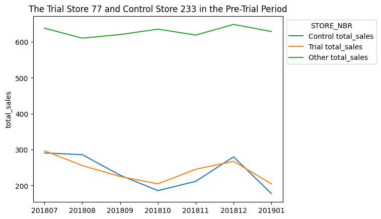

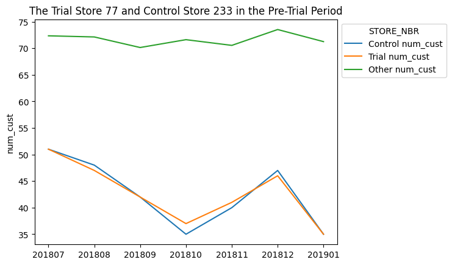

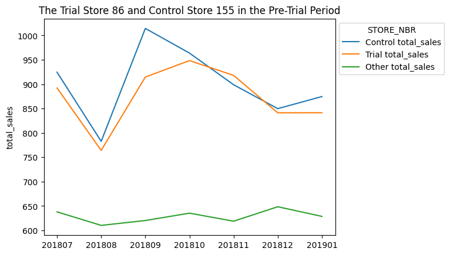

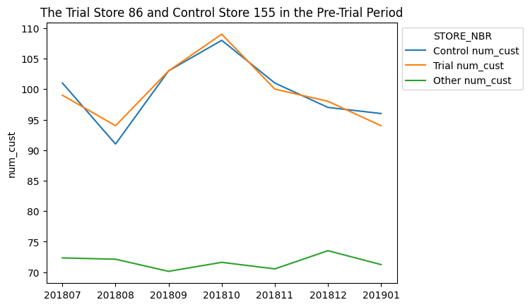

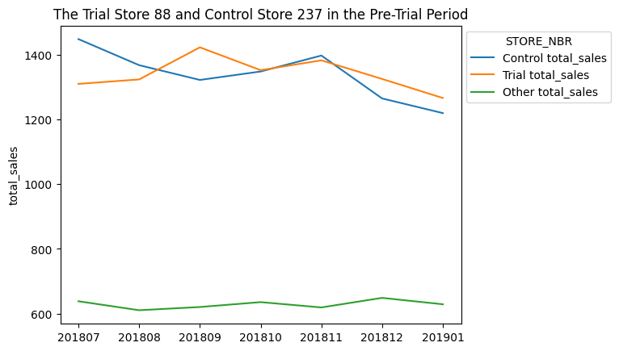

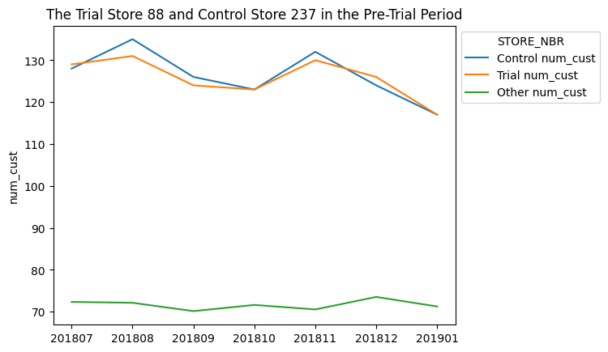

```python
storepair = [[77, 233], [86, 155], [88, 237]]
metric_col = ['total_sales', 'num_cust']
for pair in storepair:
    for metric in metric_col:
        make_plots(pair, metric)
```

The metrics of the control and trial stores look reasonably similar in the pre-trial period.

## Assessment of Trial

The trial period goes from the start of February 2019 to April 2019. Now, we want to see if there has been an uplift in overall chip sales. We'll start with scaling the control store's sales to a level similar to control for any differences between the two stores outside of the trial period.

```python
## Scale pre-trial control sales to match pre-trial trial store sales
```

```python
# Calculate Scaling Factor
scale_store77 = preTrialMeasures[preTrialMeasures.STORE_NBR == 77]['total_sales'].sum()/preTrialMeasures[preTrialMeasures.STORE_NBR == 233]['total_sales'].sum()
scale_store86 = preTrialMeasures[preTrialMeasures.STORE_NBR == 86]['total_sales'].sum()/preTrialMeasures[preTrialMeasures.STORE_NBR == 155]['total_sales'].sum()
scale_store88 = preTrialMeasures[preTrialMeasures.STORE_NBR == 88]['total_sales'].sum()/preTrialMeasures[preTrialMeasures.STORE_NBR == 237]['total_sales'].sum()
```

```python
# Extract the control store data and scale according to the store
scaled_control233 = metrics_df[metrics_df.STORE_NBR.isin([233])][['STORE_NBR', "YEARMONTH", 'total_sales']]
scaled_control233.total_sales *= scale_store77

scaled_control155 = metrics_df[metrics_df.STORE_NBR.isin([155])][['STORE_NBR', "YEARMONTH", 'total_sales']]
scaled_control155.total_sales *= scale_store86

scaled_control237 = metrics_df[metrics_df.STORE_NBR.isin([237])][['STORE_NBR', "YEARMONTH", 'total_sales']]
scaled_control237.total_sales *= scale_store88
```

```python
# Combine the scaled control stores to a single df
scaledsales_control = pd.concat([scaled_control233, scaled_control155, scaled_control237]).reset_index(drop = True)
scaledsales_control = scaledsales_control.rename(columns = {'total_sales':'scaled_total_sales', 'STORE_NBR': 'CONTROL_NBR'})

# Get the trial period of scaled control stores
scaledsales_control_trial = scaledsales_control[(scaledsales_control.YEARMONTH >= 201902) & (scaledsales_control.YEARMONTH <= 201904)].reset_index(drop = True)
```

```python
# Get the trial period of the trial stores
trialsales = metrics_df[metrics_df.STORE_NBR.isin([77,86,88])][['STORE_NBR', "YEARMONTH", 'total_sales']].reset_index(drop = True)
trialsales = trialsales.rename(columns = {'STORE_NBR': 'TRIAL_NBR'})
trialsales_trial = trialsales[(trialsales.YEARMONTH >= 201902) & (trialsales.YEARMONTH <= 201904)].reset_index(drop = True)
```

```python
# Calculate the percentage difference between the control and trial store pairs for each month over the year
percentdiff = scaledsales_control.copy()
percentdiff[['TRIAL_NBR', 'total_sales_t']] = trialsales[['TRIAL_NBR', 'total_sales']]
percentdiff = percentdiff.rename(columns = {'scaled_total_sales' : 'scaled_sales_c'})
percentdiff['sales_percent_diff'] = (percentdiff.total_sales_t - percentdiff.scaled_sales_c)\
                                    /(0.5*((percentdiff.scaled_sales_c + percentdiff.total_sales_t)))
percentdiff.head()
```

|  | CONTROL_NBR | YEARMONTH | scaled_sales_c | TRIAL_NBR | total_sales_t | sales_percent_diff |
| --- | --- | --- | --- | --- | --- | --- |
| 0 | 233 | 201807 | 297.565550 | 77 | 296.8 | -0.002576 |
| 1 | 233 | 201808 | 292.652187 | 77 | 255.5 | -0.135554 |
| 2 | 233 | 201809 | 233.998916 | 77 | 225.2 | -0.038323 |
| 3 | 233 | 201810 | 190.085733 | 77 | 204.5 | 0.073060 |
| 4 | 233 | 201811 | 216.597421 | 77 | 245.3 | 0.124281 |

Let's see if the difference is significant (use t-test)! As our null hypothesis is that the trial period is the same as the pre-trial period, let's take the standard deviation based on the scaled percentage difference in the pre-trial period

```python
pretrial_percentdiff = percentdiff[percentdiff.YEARMONTH < 201902]
pretrial_percentdiff_std = pretrial_percentdiff.groupby(['TRIAL_NBR'])['sales_percent_diff'].agg('std').reset_index()
dof = 6 # 7 months of data - 1

for stores in storepair: # stores numbers are stored as [trial, control] in storepair
    trialstore = stores[0]
    controlstore = stores[1]
    pretrial = percentdiff[(percentdiff.YEARMONTH < 201902) & (percentdiff.TRIAL_NBR == trialstore)]
    std = pretrial['sales_percent_diff'].agg('std')
    mean =  pretrial['sales_percent_diff'].agg('mean')
    trialperiod = percentdiff[(percentdiff.YEARMONTH >= 201902) & (percentdiff.YEARMONTH <= 201904) \
                              & (percentdiff.TRIAL_NBR == trialstore)]
    print("Trial store -", trialstore, "; control store -", controlstore)
    print("Month : t-statistic")
    for month in trialperiod.YEARMONTH.unique():
        xval = trialperiod[trialperiod.YEARMONTH == month]['sales_percent_diff'].item()
        tstat = ((xval - mean) / std)
        print(str(month), ' : ', tstat)
    print()

# Generate the t-statistic for the 95% percentile with 6 dof
print ('95th percentile value:', stats.t.ppf(1-0.05, 6))
```

```
Trial store - 77 ; control store - 233
Month : t-statistic
201902  :  -0.7171038288055838
201903  :  3.035317928855674
201904  :  4.708944418758219

Trial store - 86 ; control store - 155
Month : t-statistic
201902  :  1.4133618775921597
201903  :  7.123063846042147
201904  :  0.8863824572944234

Trial store - 88 ; control store - 237
Month : t-statistic
201902  :  -0.47141665284272455
201903  :  3.412844621973537
201904  :  3.0208537098693133

95th percentile value: 1.9431802805153022
```

We can observe that the t-value for the trial store 77 is much larger than the 95th percentile value of the t-distribution for March and April - i.e. the increase in sales in the trial store 77 in March and April is statistically greater than in the control store. This can also be seen for March of trial store 86.

Let's create a more visual version of this by plotting the sales of the control store, the sales of the trial stores and the 95th percentile value of sales of the control store.

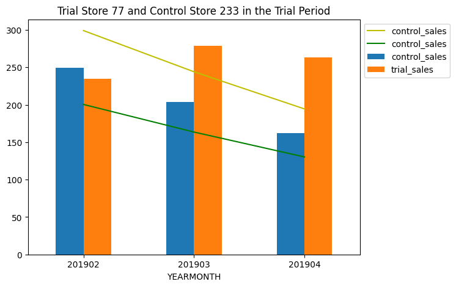

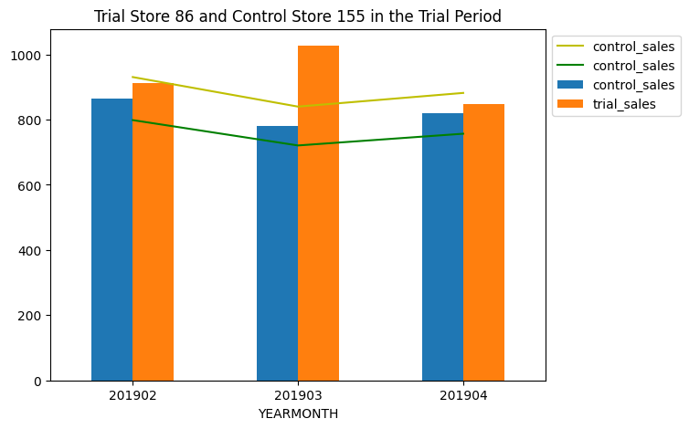

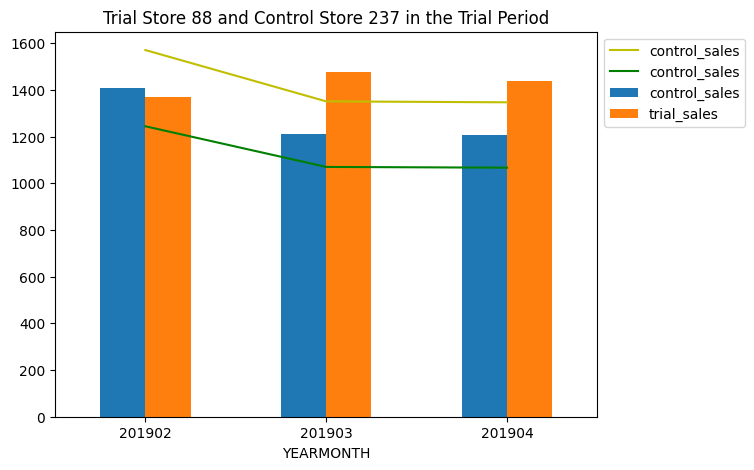

```python
# First do bar graphs during the trial period
storepair = [[77, 233], [86, 155], [88, 237]]
for stores in storepair: # stores numbers are stored as [trial, control] in storepair
    trial = stores[0]
    control = stores[1]

    # Plot the bar chart of sales performance
    plot_control = percentdiff[(percentdiff['CONTROL_NBR'] == control) & (percentdiff.YEARMONTH >= 201902) & (percentdiff.YEARMONTH <= 201904)]\
                    [['YEARMONTH', 'CONTROL_NBR', 'scaled_sales_c']]
    plot_control = plot_control.rename(columns = {"CONTROL_NBR" : "STORE_NBR", "scaled_sales_c": "control_sales"})
    plot_trial = percentdiff[(percentdiff['TRIAL_NBR'] == trial) & (percentdiff.YEARMONTH >= 201902) & (percentdiff.YEARMONTH <= 201904)]\
                    [['YEARMONTH', 'TRIAL_NBR', 'total_sales_t']]
    plot_trial = plot_trial.rename(columns = {"TRIAL_NBR" : "STORE_NBR", "total_sales_t": "trial_sales"})
    toplot = plot_control[["YEARMONTH", "control_sales"]].merge(plot_trial[["YEARMONTH", "trial_sales"]],on="YEARMONTH").set_index("YEARMONTH")
    ax = toplot.plot(kind = 'bar',  figsize=(7, 5))

    # plot the thresholds as lines
    std = percentdiff[(percentdiff['CONTROL_NBR'] == control) & (percentdiff.YEARMONTH < 201902)]['sales_percent_diff'].std()
    threshold95 = plot_control.reset_index()[['YEARMONTH', 'control_sales']]
    threshold95.control_sales = threshold95.control_sales*(1+std*2)
    threshold5 = plot_control.reset_index()[['YEARMONTH', 'control_sales']]
    threshold5.control_sales = threshold5.control_sales*(1-std*2)
    ax95 = threshold95.plot.line(x = 'YEARMONTH', y = 'control_sales',color='y', figsize=(7, 5), use_index=False, ax = ax)
    ax5 = threshold5.plot.line(x = 'YEARMONTH', y = 'control_sales', color='g', figsize=(7, 5), use_index=False, ax = ax)

    plt.legend(loc = "upper left",bbox_to_anchor=(1.0, 1.0))
    titlestr = 'Trial Store ' + str(trial) + ' and Control Store ' + str(control) + ' in the Trial Period'
    ax.set_title(titlestr)
    plt.show()
```

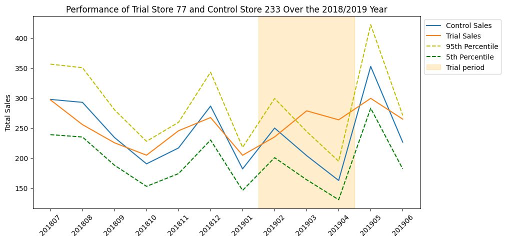

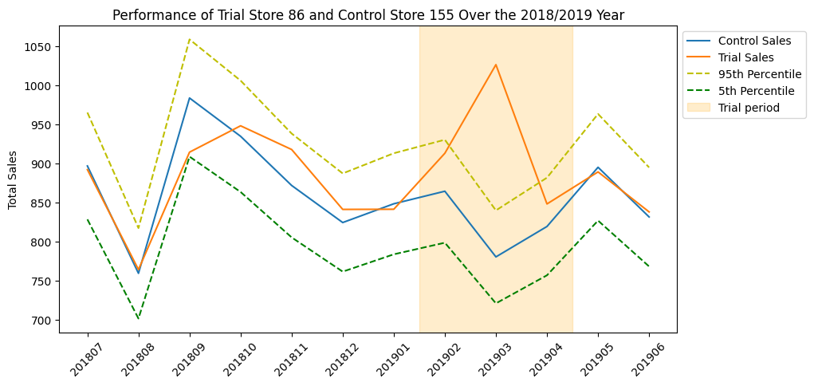

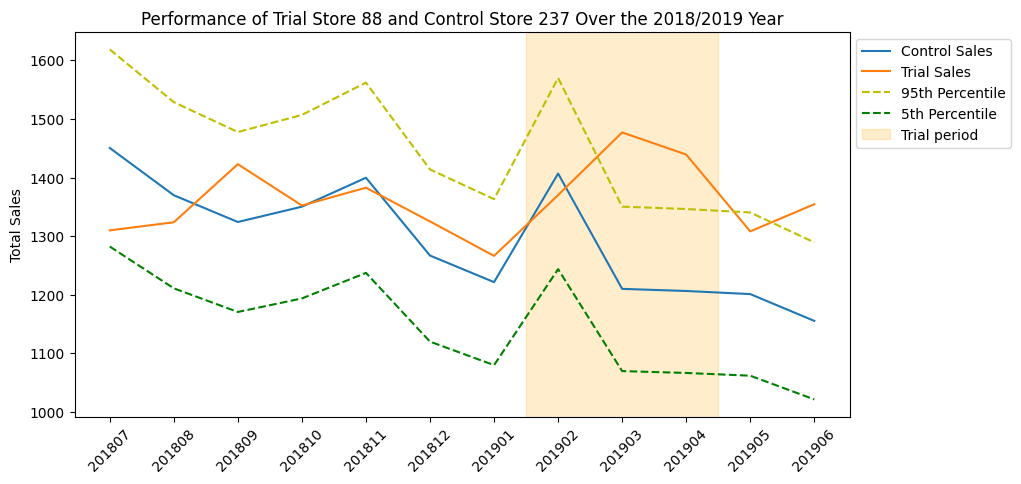

```python
# Then do line graphs during the whole year - for the report
from matplotlib.patches import Rectangle
storepair = [[77, 233], [86, 155], [88, 237]]
for stores in storepair:
    trial = stores[0]
    control = stores[1]

    # Plot the line graph of sales performance
    plot_control = percentdiff[(percentdiff['CONTROL_NBR'] == control)][['YEARMONTH', 'CONTROL_NBR', 'scaled_sales_c']]
    plot_control = plot_control.rename(columns = {"CONTROL_NBR" : "STORE_NBR", "scaled_sales_c": "control_sales"})
    plot_trial = percentdiff[(percentdiff['TRIAL_NBR'] == trial)][['YEARMONTH', 'TRIAL_NBR', 'total_sales_t']]
    plot_trial = plot_trial.rename(columns = {"TRIAL_NBR" : "STORE_NBR", "total_sales_t": "trial_sales"})

    ax = plot_control.plot.line(x = "YEARMONTH", y = 'control_sales', use_index=False, label = 'Control Sales')
    ax_trial = plot_trial.plot.line(x = "YEARMONTH", y = 'trial_sales', use_index=False, ax=ax, label = 'Trial Sales')


    # plot the thresholds as lines
    std = percentdiff[(percentdiff['CONTROL_NBR'] == control) & (percentdiff.YEARMONTH < 201902)]['sales_percent_diff'].std()
    threshold95 = plot_control.reset_index()[['YEARMONTH', 'control_sales']]
    threshold95.control_sales = threshold95.control_sales*(1+std*2)
    threshold5 = plot_control.reset_index()[['YEARMONTH', 'control_sales']]
    threshold5.control_sales = threshold5.control_sales*(1-std*2)
    ax95 = threshold95.plot.line(x = 'YEARMONTH', y = 'control_sales',color='y', linestyle = '--', figsize=(10, 5), use_index=False, ax = ax, label = '95th Percentile')
    ax5 = threshold5.plot.line(x = 'YEARMONTH', y = 'control_sales', color='g',  linestyle = '--', figsize=(10, 5), use_index=False, ax = ax, label = '5th Percentile')
    ax.add_patch(Rectangle((6.5, 0), 3, 2000, alpha = 0.2, label = 'Trial period', color='orange'))

    # Other plot features
    ax.set_ylabel('Total Sales')
    plt.legend(loc = "upper left",bbox_to_anchor=(1.0, 1.0))
    titlestr = 'Performance of Trial Store ' + str(trial) + ' and Control Store ' + str(control) + ' Over the 2018/2019 Year'
    positions = (0,1,2,3,4,5,6,7,8,9, 10, 11)
    labels = ("201807", '201808', '201809', '201810', '201811', '201812', '201901', '201902', '201903', '201904', '201905', '201906')
    plt.xticks (positions, labels, rotation=45)
    ax.set_title(titlestr)
    plt.show()
```

The results show that the trial in store 77 is significantly different to its control store in the trial period as the trial store performance lies outside the 5% to 95% confidence interval of the control store in two of the three trial months.

For store 86, we can see that the trial in March is significantly different to the control store with the total sales performance outside of the 5% to 95% confidence interval. However, there is no significant difference in February's and April's performance.

```python
# Let's have a look at assessing this for number of customers as well.
```

```python
# Calculate the scaling factor for the store pairs
scale_store77 = preTrialMeasures[preTrialMeasures.STORE_NBR == 77]['num_cust'].sum()/preTrialMeasures[preTrialMeasures.STORE_NBR == 233]['num_cust'].sum()
scale_store86 = preTrialMeasures[preTrialMeasures.STORE_NBR == 86]['num_cust'].sum()/preTrialMeasures[preTrialMeasures.STORE_NBR == 155]['num_cust'].sum()
scale_store88 = preTrialMeasures[preTrialMeasures.STORE_NBR == 88]['num_cust'].sum()/preTrialMeasures[preTrialMeasures.STORE_NBR == 237]['num_cust'].sum()
```

```python
# Extract the control store data from the df and scale according to the store
scaled_control233 = metrics_df[metrics_df.STORE_NBR.isin([233])][['STORE_NBR', "YEARMONTH", 'num_cust']]
scaled_control233.num_cust *= scale_store77
scaled_control155 = metrics_df[metrics_df.STORE_NBR.isin([155])][['STORE_NBR', "YEARMONTH", 'num_cust']]
scaled_control155.num_cust *= scale_store86
scaled_control237 = metrics_df[metrics_df.STORE_NBR.isin([237])][['STORE_NBR', "YEARMONTH", 'num_cust']]
scaled_control237.num_cust *= scale_store88

# Combine the scaled control stores to a single df
scaledncust_control = pd.concat([scaled_control233, scaled_control155, scaled_control237]).reset_index(drop = True)
scaledncust_control = scaledncust_control.rename(columns = {'num_cust':'scaled_n_cust', 'STORE_NBR': 'CONTROL_NBR'})
# Get the trial period of scaled control stores
scaledncust_control_trial = scaledncust_control[(scaledsales_control.YEARMONTH >= 201902) & (scaledsales_control.YEARMONTH <= 201904)].reset_index(drop = True)

# Get the trial period of the trial stores
trialncust = metrics_df[metrics_df.STORE_NBR.isin([77,86,88])][['STORE_NBR', "YEARMONTH", 'num_cust']].reset_index(drop = True)
trialncust = trialncust.rename(columns = {'STORE_NBR': 'TRIAL_NBR'})
trialncust_trial = trialncust[(trialncust.YEARMONTH >= 201902) & (trialsales.YEARMONTH <= 201904)].reset_index(drop = True)
```

```python
# Calculate the percentage difference between the control and trial store pairs for each month over the year
percentdiff = scaledncust_control.copy()
percentdiff[['TRIAL_NBR', 'n_cust_t']] = trialncust[['TRIAL_NBR', 'num_cust']]
percentdiff = percentdiff.rename(columns = {'scaled_n_cust' : 'scaled_n_cust_c'})
percentdiff['cust_percent_diff'] = (percentdiff.n_cust_t-percentdiff.scaled_n_cust_c)\
                                    /(0.5*((percentdiff.scaled_n_cust_c+percentdiff.n_cust_t)))
percentdiff.head()
```

|  | CONTROL_NBR | YEARMONTH | scaled_n_cust_c | TRIAL_NBR | n_cust_t | cust_percent_diff |
| --- | --- | --- | --- | --- | --- | --- |
| 0 | 233 | 201807 | 51.171141 | 77 | 51 | -0.003350 |
| 1 | 233 | 201808 | 48.161074 | 77 | 47 | -0.024402 |
| 2 | 233 | 201809 | 42.140940 | 77 | 42 | -0.003350 |
| 3 | 233 | 201810 | 35.117450 | 77 | 37 | 0.052208 |
| 4 | 233 | 201811 | 40.134228 | 77 | 41 | 0.021342 |

```python
# As our null hypothesis is that the trial period is the same as the pre-trial period,
# let's take the standard deviation based on the scaled percentage difference in the pre-trial period.
```

```python
pretrial_percentdiff = percentdiff[percentdiff.YEARMONTH < 201902]
pretrial_percentdiff_std = pretrial_percentdiff.groupby(['TRIAL_NBR'])['cust_percent_diff'].agg('std').reset_index()
dof = 6 # 7 months of data - 1

for stores in storepair: # stores numbers are stored as [trial, control] in storepair
    trialstore = stores[0]
    controlstore = stores[1]
    pretrial = percentdiff[(percentdiff.YEARMONTH < 201902) & (percentdiff.TRIAL_NBR == trialstore)]
    std = pretrial['cust_percent_diff'].agg('std')
    mean =  pretrial['cust_percent_diff'].agg('mean')
    trialperiod = percentdiff[(percentdiff.YEARMONTH >= 201902) & (percentdiff.YEARMONTH <= 201904) \
                              & (percentdiff.TRIAL_NBR == trialstore)]
    print("Trial store -", trialstore, "; control store -", controlstore)
    print("Month : t-statistic")
    for month in trialperiod.YEARMONTH.unique():
        xval = trialperiod[trialperiod.YEARMONTH == month]['cust_percent_diff'].item()
        tstat = ((xval - mean)/std)
        print(str(month), ' : ', tstat)
    print()

# Generate the t-statistic for the 95% percentile with 6 dof
print ('95th percentile value:', stats.t.ppf(1-0.05, 6))
```

```
Trial store - 77 ; control store - 233
Month : t-statistic
201902  :  -0.19886295797440687
201903  :  8.009609025380932
201904  :  16.114474772873923

Trial store - 86 ; control store - 155
Month : t-statistic
201902  :  6.220524882227514
201903  :  10.52599074274189
201904  :  3.0763575852842706

Trial store - 88 ; control store - 237
Month : t-statistic
201902  :  -0.6706311831628834
201903  :  7.815002207822421
201904  :  4.406627816109982

95th percentile value: 1.9431802805153022
```

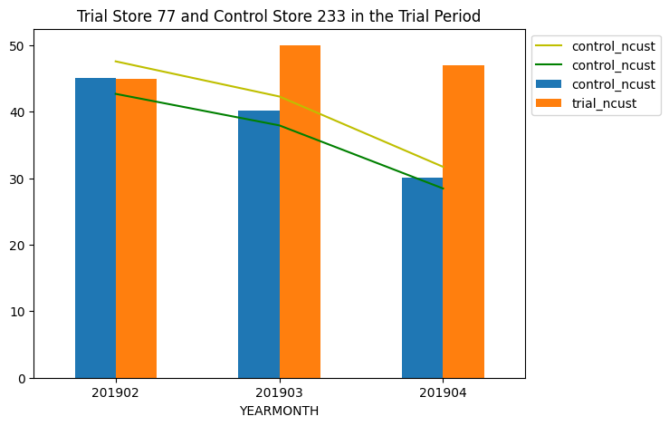

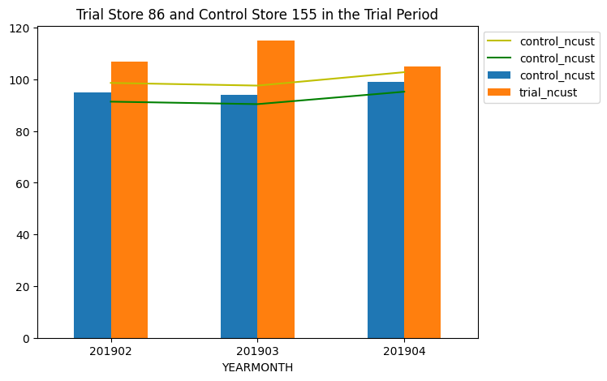

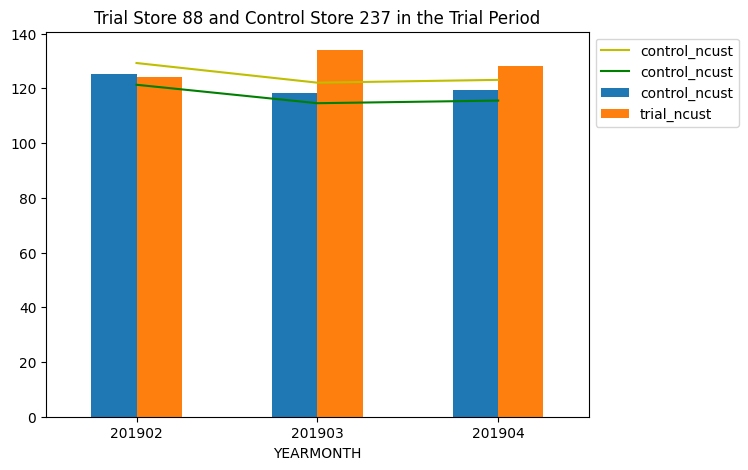

```python
# First do bar charts to focus on the trial period
storepair = [[77, 233], [86, 155], [88, 237]]
for stores in storepair: # stores numbers are stored as [trial, control] in storepair
    trial = stores[0]
    control = stores[1]
    plot_control = percentdiff[(percentdiff['CONTROL_NBR'] == control) & (percentdiff.YEARMONTH >= 201902) & (percentdiff.YEARMONTH <= 201904)]\
                    [['YEARMONTH', 'CONTROL_NBR', 'scaled_n_cust_c']]
    plot_control = plot_control.rename(columns = {"CONTROL_NBR" : "STORE_NBR", "scaled_n_cust_c": "control_ncust"})
    plot_trial = percentdiff[(percentdiff['TRIAL_NBR'] == trial) & (percentdiff.YEARMONTH >= 201902) & (percentdiff.YEARMONTH <= 201904)]\
                    [['YEARMONTH', 'TRIAL_NBR', 'n_cust_t']]
    plot_trial = plot_trial.rename(columns = {"TRIAL_NBR" : "STORE_NBR", "n_cust_t": "trial_ncust"})
    toplot = plot_control[["YEARMONTH", "control_ncust"]].merge(plot_trial[["YEARMONTH", "trial_ncust"]],on="YEARMONTH").set_index("YEARMONTH")
    ax = toplot.plot(kind = 'bar',  figsize=(7, 5))


    # plot the thresholds as lines
    std = percentdiff[(percentdiff['CONTROL_NBR'] == control) & (percentdiff.YEARMONTH < 201902)]['cust_percent_diff'].std()
    threshold95 = plot_control.reset_index()[['YEARMONTH', 'control_ncust']]
    threshold95.control_ncust = threshold95.control_ncust*(1+std*2)
    threshold5 = plot_control.reset_index()[['YEARMONTH', 'control_ncust']]
    threshold5.control_ncust = threshold5.control_ncust*(1-std*2)
    ax95 = threshold95.plot.line(x = 'YEARMONTH', y = 'control_ncust',color='y', figsize=(7, 5), use_index=False, ax = ax)
    ax5 = threshold5.plot.line(x = 'YEARMONTH', y = 'control_ncust', color='g', figsize=(7, 5), use_index=False, ax = ax)

    # Other plot features
    plt.legend(loc = "upper left",bbox_to_anchor=(1.0, 1.0))
    titlestr = 'Trial Store ' + str(trial) + ' and Control Store ' + str(control) + ' in the Trial Period'
    ax.set_title(titlestr)
    plt.show()
```

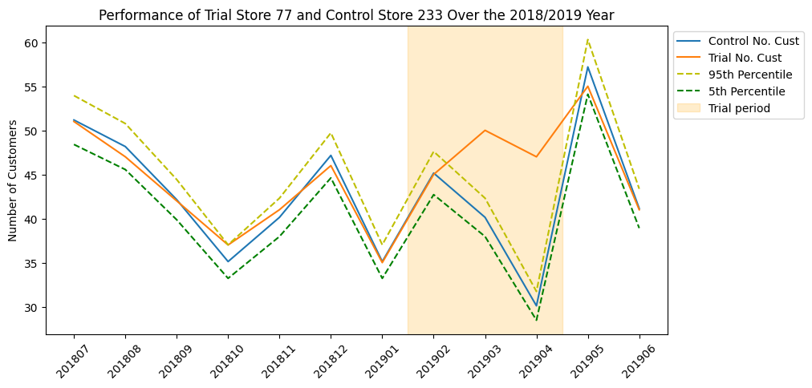

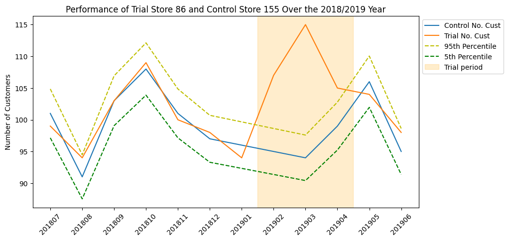

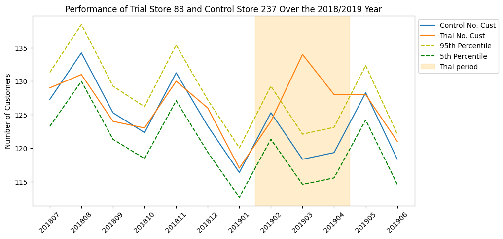

```python
# Then do line graphs to show a full year's trend
storepair = [[77, 233], [86, 155], [88, 237]]
for stores in storepair: # stores numbers are stored as [trial, control] in storepair
    trial = stores[0]
    control = stores[1]
    plot_control = percentdiff[(percentdiff['CONTROL_NBR'] == control)]\
                    [['YEARMONTH', 'CONTROL_NBR', 'scaled_n_cust_c']]
    plot_control = plot_control.rename(columns = {"CONTROL_NBR" : "STORE_NBR", "scaled_n_cust_c": "control_ncust"})
    plot_trial = percentdiff[(percentdiff['TRIAL_NBR'] == trial)]\
                    [['YEARMONTH', 'TRIAL_NBR', 'n_cust_t']]
    plot_trial = plot_trial.rename(columns = {"TRIAL_NBR" : "STORE_NBR", "n_cust_t": "trial_ncust"})

    ax = plot_control.plot.line(x = "YEARMONTH", y = 'control_ncust', use_index=False, label = 'Control No. Cust')
    ax_trial = plot_trial.plot.line(x = "YEARMONTH", y = 'trial_ncust', use_index=False, ax=ax, label = 'Trial No. Cust')

    # plot the thresholds as lines
    std = percentdiff[(percentdiff['CONTROL_NBR'] == control) & (percentdiff.YEARMONTH < 201902)]['cust_percent_diff'].std()
    threshold95 = plot_control.reset_index()[['YEARMONTH', 'control_ncust']]
    threshold95.control_ncust = threshold95.control_ncust*(1+std*2)
    threshold5 = plot_control.reset_index()[['YEARMONTH', 'control_ncust']]
    threshold5.control_ncust = threshold5.control_ncust*(1-std*2)
    ax95 = threshold95.plot.line(x = 'YEARMONTH', y = 'control_ncust',color='y', linestyle = '--', figsize=(10, 5), use_index=False, ax = ax, label = '95th Percentile')
    ax5 = threshold5.plot.line(x = 'YEARMONTH', y = 'control_ncust', color='g',  linestyle = '--', figsize=(10, 5), use_index=False, ax = ax, label = '5th Percentile')
    ax.add_patch(Rectangle((6.5, 0), 3, 2000, alpha = 0.2, label = 'Trial period', color='orange'))

    # Other plot features
    ax.set_ylabel('Number of Customers')
    plt.legend(loc = "upper left",bbox_to_anchor=(1.0, 1.0))
    titlestr = 'Performance of Trial Store ' + str(trial) + ' and Control Store ' + str(control) + ' Over the 2018/2019 Year'
    positions = (0,1,2,3,4,5,6,7,8,9, 10, 11)
    labels = ("201807", '201808', '201809', '201810', '201811', '201812', '201901', '201902', '201903', '201904', '201905', '201906')
    plt.xticks (positions, labels, rotation=45)
    ax.set_title(titlestr)
    plt.show()
```